# Transposon mutagenesis in *GAP1* CNV strains

Grace Avecilla

February 10, 2020

# Figure 1

```r
#Read in illustrator figures for 1A and 1B, data for 1C
f1a = readPNG("./illustrator_figures/Fig1A.png")
f1b = readPNG("./illustrator_figures/Fig1B.png")
f1c_data = read_csv('./figure_data/Fig1C.csv')
```

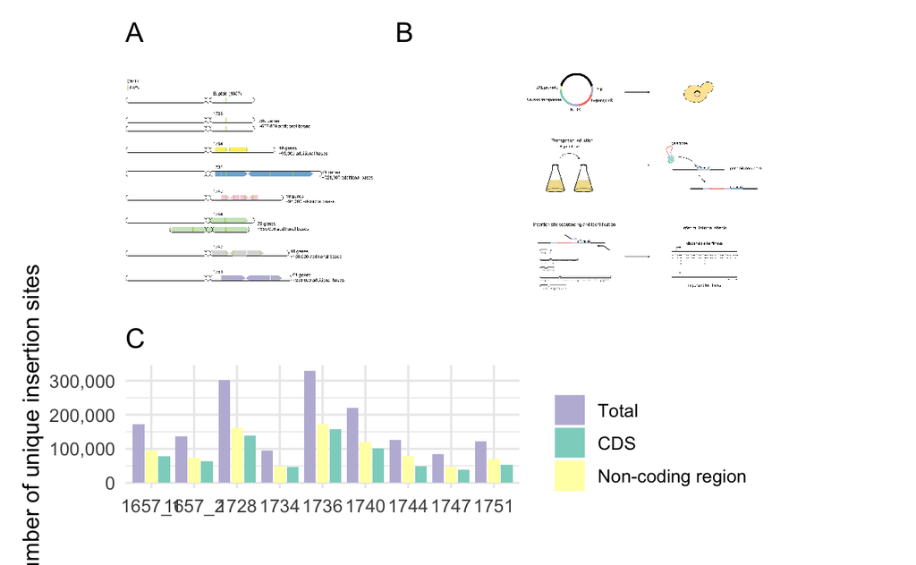

```r
a = ggplot() +
  background_image(f1a) +
  coord_fixed() +
  ggtitle("A")
b = ggplot() +
  background_image(f1b) +
  coord_fixed() +
  ggtitle("B")
c = ggplot(f1c_data, aes(sample, value, fill=location_type)) +
  geom_bar(stat = "identity", position=position_dodge2(reverse = TRUE)) +
  scale_fill_brewer(name ="",
                      breaks=c("total_sites", "total_insertions_in_genes", "total_insertions_noncoding"),
                         labels=c("Total", "CDS", "Non-coding region"), palette = "Set3") +
  ylab("Number of unique insertion sites") +
  xlab('') +
  scale_y_continuous(labels = scales::comma) +
  #theme(legend.position="top") +
  ggtitle("C")

designF1 <- "
  1122
  1122
  333#
"

Fig1 = a + b + c + plot_layout(design = designF1)
Fig1
ggsave("Figure1.pdf", plot = Fig1, width = 13, height = 9, units = "in")
```

**Figure 1 Hermes transposon insertion results in genome wide mutagenesis in euploid and CNV yeast strains** **A.** The experiment was performed on a euploid *S. cerevisiae* strain and seven strains that have CNVs which include *GAP1*. The hypothesized structure of each *GAP1* CNV is diagrammed; the amplified region is shown as a colored block with arrows. Arrows pointing right represent copies that maintain their original orientation, arrows point left represent copies that are inverted. **B.** Plasmids containing the hermes transposase under the *GALS* (truncated *GAL1*) promoter and a hygromycin resistance gene flanked by the hermes terminal inverted repeats (TIR). Upon addition of galactose to the media, the transposase is expressed, and the hygromycin resistance gene flanked by the TIRs is excised from the plasmid and inserted in the yeast genome. Insertion sites are identified by targeted PCR and amplicon sequencing, and mutational effects are inferred by the number of unique insertion sites at different regions of the genome. **C.** After insertion mutagenesis in each CNV strain and in two biological replicates of the euploid strain (16757_1 and 1657_2), the total number of unique insertion sites in each experiment was identified (purple). Strains have more unique insertion sites in non-coding regions (yellow), than coding regions (green).

# Figure 2

Fig2A Essential euploid, nonessential CNV Fig2B Volcano plot all CNV vs all euploid Fig2C gsea on ranked list fold change for all CNV vs euploid & each CNV strain vs euploid Fig2D Significantly different gene insertion reveal allele specific genetic interactions

- Note: I am going to do differential analysis on the 100 bp windows - if this turns up interesting results, should they be included in this figure? What should that look like?*

```r
# read in data
f2a = read.csv("./figure_data/Fig2A.csv")
f2b = read.csv("./figure_data/Fig2B.csv")
f2c = read.csv("./figure_data/Fig2C.csv")
f2d = read.csv("./figure_data/Fig2D.csv")
```

```r
d = ggplot(f2d, aes(as.character(strain), common_name, fill = log2FoldChange)) +
  geom_tile() +
  scale_fill_gradient2(low = "blue", mid = "white", high = "red") +
  theme_blank()
```

[output not shown]

# Figure 3 Amplified genes

# Figure 4

# Table 1

# Data that is important but too small to make a figure/table of

- There is one gene (RRN10), that has 0 insertions in any CNV strains, but has 1 insertion in 1657_1, and 2 insertions in 1657_2

# Supplementary Figure 1.1

SFig1.1A WGS read depth before experiment SFig1.1B WGS read depth after experiment SFig1.1C normalized reads/gene before and after tn mutagenesis?

# Supplementary Figure 1.2

SFig1.2A Spearman correlation SFig1.2B Insertion coverage over the genome SFig1.2C Number of hermes insertions vs. number of WGS reads?

```r
# read in data
fs1.2b = read_csv("./figure_data/FigS1.2B.csv")
```

```r
b = ggplot(cov_df, aes(bin_start, coverage, fill = chromosome)) +
  facet_grid(sample ~ chromosome, scales = "free") +
  ylab("unique insertion sites/100 bp bin") +
  xlab("Bin start position")
  geom_point_rast() # should I add a running mean here? or make windows smaller?
```

# Supplementary Figure 2.1 Insertion profiles recover known essential genes

SFig2.1A Barplots number of insertions in ACT1 vs average SFig2.1B metagene plots essential vs non-essential genes

SFig2.1A Normalized insertions/gene for genes in Fig2D

# Supplementary Figure 2.2 Differential analysis and GSEA excluding amplified genes

# Supplementary Table X Full GSEA outputs

## Here are normalized insertions per gene for the genes we will validate

```r
val_genes_ipg_norm = ipg_norm %>%
  filter(gene %in% c("YER177W","YDR099W", "YOR371C", "YAL056W", "YOL110W", "YDR011W", "YOR153W", "YPL230W")) %>% mutate(gene_name = NA)

for(i in 1:nrow(val_genes_ipg_norm) ){
  val_genes_ipg_norm$gene_name[i] =
    bitr(val_genes_ipg_norm$gene[i], fromType = "ORF", toType = "GENENAME", OrgDb = org.Sc.sgd.db::org.Sc.sgd.db)$GENENAME
}

ggplot(val_genes_ipg_norm,
       aes(gene_name, norm_insertions_per_gene, fill = sample)) +
  geom_bar(stat = "identity", position = "dodge") +
  scale_fill_brewer(palette="Set3") +
  xlab("") +
  ylab("Normalized insertions/gene")
```

[output not shown]

####references#### * FACS analysis from previous study showed that in the absence of budding yeast 14-3-3 proteins, cells spend most of their time in S phase and cell takes more time for duplication of its genetic content (Lotterberger et al., 2006). * C. Wang, C. Skinner, E. Easlon, S.J. Lin Deleting the 14-3-3 protein Bmh1 extends life span in Saccharomyces cerevisiae by increasing stress response